# WEATHER PROJECT

```python
import pandas as pd
import matplotlib.pyplot as plt
import seaborn as sns
import numpy as np
```

```python
df = pd.read_csv(r"C:\Users\Josphat\Documents\DATASETS\weatherHistory.csv")
df.head()
```

|  | Formatted Date | Summary | Precip Type | Temperature (C) | Apparent Temperature (C) | Humidity | Wind Speed (km/h) | Wind Bearing (degrees) | Visibility (km) | Loud Cover | Pressure (millibars) | Daily Summary |
| --- | --- | --- | --- | --- | --- | --- | --- | --- | --- | --- | --- | --- |
| 0 | 2006-04-01 00:00:00.000 +0200 | Partly Cloudy | rain | 9.472222 | 7.388889 | 0.89 | 14.1197 | 251.0 | 15.8263 | 0.0 | 1015.13 | Partly cloudy throughout the day. |
| 1 | 2006-04-01 01:00:00.000 +0200 | Partly Cloudy | rain | 9.355556 | 7.227778 | 0.86 | 14.2646 | 259.0 | 15.8263 | 0.0 | 1015.63 | Partly cloudy throughout the day. |
| 2 | 2006-04-01 02:00:00.000 +0200 | Mostly Cloudy | rain | 9.377778 | 9.377778 | 0.89 | 3.9284 | 204.0 | 14.9569 | 0.0 | 1015.94 | Partly cloudy throughout the day. |
| 3 | 2006-04-01 03:00:00.000 +0200 | Partly Cloudy | rain | 8.288889 | 5.944444 | 0.83 | 14.1036 | 269.0 | 15.8263 | 0.0 | 1016.41 | Partly cloudy throughout the day. |
| 4 | 2006-04-01 04:00:00.000 +0200 | Mostly Cloudy | rain | 8.755556 | 6.977778 | 0.83 | 11.0446 | 259.0 | 15.8263 | 0.0 | 1016.51 | Partly cloudy throughout the day. |

```python
# Convert 'Formatted Date' to datetime
df['Formatted Date'] = pd.to_datetime(df['Formatted Date'],utc=True)
```

```python
df = df.rename(columns={'Precip Type': 'Weather'})
```

```python
df.shape
columns = df.columns
print(columns)
```

```
Index(['Formatted Date', 'Summary', 'Weather', 'Temperature (C)',
       'Apparent Temperature (C)', 'Humidity', 'Wind Speed (km/h)',
       'Wind Bearing (degrees)', 'Visibility (km)', 'Loud Cover',
       'Pressure (millibars)', 'Daily Summary'],
      dtype='object')
```

```python
df.index
```

```
RangeIndex(start=0, stop=96453, step=1)
```

```python
df.dtypes
```

[output not shown]

```python
df['Weather'].unique()
```

```
array(['rain', 'snow', nan], dtype=object)
```

```python
df.nunique()
```

```
Formatted Date              96429
Summary                        27
Weather                         2
Temperature (C)              7574
Apparent Temperature (C)     8984
Humidity                       90
Wind Speed (km/h)            2484
Wind Bearing (degrees)        360
Visibility (km)               949
Loud Cover                      1
Pressure (millibars)         4979
Daily Summary                 214
dtype: int64
```

```python
df.count()
```

[output not shown]

```python
df['Weather'].value_counts
```

```
<bound method IndexOpsMixin.value_counts of 0        rain
1        rain
2        rain
3        rain
4        rain
         ...
96448    rain
96449    rain
96450    rain
96451    rain
96452    rain
Name: Weather, Length: 96453, dtype: object>
```

```python
df.info()
```

```
<class 'pandas.core.frame.DataFrame'>
RangeIndex: 96453 entries, 0 to 96452
Data columns (total 12 columns):
 #   Column                    Non-Null Count  Dtype
---  ------                    --------------  -----
 0   Formatted Date            96453 non-null  datetime64[ns, UTC]
 1   Summary                   96453 non-null  object
 2   Weather                   95936 non-null  object
 3   Temperature (C)           96453 non-null  float64
 4   Apparent Temperature (C)  96453 non-null  float64
 5   Humidity                  96453 non-null  float64
 6   Wind Speed (km/h)         96453 non-null  float64
 7   Wind Bearing (degrees)    96453 non-null  float64
 8   Visibility (km)           96453 non-null  float64
 9   Loud Cover                96453 non-null  float64
 10  Pressure (millibars)      96453 non-null  float64
 11  Daily Summary             96453 non-null  object
dtypes: datetime64[ns, UTC](1), float64(8), object(3)
memory usage: 8.8+ MB
```

**1. Find all the unique 'Wind speed' values in the data**

```python
df.head(2)
df.nunique()
```

```
Formatted Date              96429
Summary                        27
Weather                         2
Temperature (C)              7574
Apparent Temperature (C)     8984
Humidity                       90
Wind Speed (km/h)            2484
Wind Bearing (degrees)        360
Visibility (km)               949
Loud Cover                      1
Pressure (millibars)         4979
Daily Summary                 214
dtype: int64
```

```python
df['Wind Speed (km/h)'].nunique()
```

```
2484
```

```python
unique = df['Wind Speed (km/h)'].unique()
print(unique) #Answer
```

```
[14.1197 14.2646  3.9284 ... 37.0622 35.5971 30.751 ]
```

```python
"""Therefore the total number of all unique values in the column of Wind Speed is 2484 as shown above and they are given in the array (unique) above"""
```

```
'Therefore the total number of all unique values in the column of Wind Speed is 2484 as shown above and they are given in the array (unique) above'
```

**2.Find the number of times when when 'Weather was exactly snow'**

```python
#Value_counts method
df.Weather.value_counts()
```

```
Weather
rain    85224
snow    10712
Name: count, dtype: int64
```

```python
#Filtering Method
df[df.Weather == 'snow']
```

|  | Formatted Date | Summary | Weather | Temperature (C) | Apparent Temperature (C) | Humidity | Wind Speed (km/h) | Wind Bearing (degrees) | Visibility (km) | Loud Cover | Pressure (millibars) | Daily Summary |
| --- | --- | --- | --- | --- | --- | --- | --- | --- | --- | --- | --- | --- |
| 1562 | 2006-12-13 01:00:00+00:00 | Foggy | snow | -0.483333 | -4.150000 | 1.00 | 11.0929 | 219.0 | 0.4830 | 0.0 | 1031.56 | Foggy throughout the day. |
| 1563 | 2006-12-13 02:00:00+00:00 | Foggy | snow | -0.483333 | -4.061111 | 0.96 | 10.7387 | 200.0 | 0.3220 | 0.0 | 1031.47 | Foggy throughout the day. |
| 1564 | 2006-12-13 03:00:00+00:00 | Foggy | snow | -0.922222 | -3.477778 | 1.00 | 7.0679 | 206.0 | 0.1610 | 0.0 | 1031.23 | Foggy throughout the day. |
| 1565 | 2006-12-13 04:00:00+00:00 | Foggy | snow | -1.038889 | -4.400000 | 1.00 | 9.4990 | 199.0 | 0.1610 | 0.0 | 1031.41 | Foggy throughout the day. |
| 1566 | 2006-12-13 05:00:00+00:00 | Foggy | snow | -1.088889 | -4.438889 | 1.00 | 9.4346 | 219.0 | 0.3220 | 0.0 | 1031.98 | Foggy throughout the day. |
| ... | ... | ... | ... | ... | ... | ... | ... | ... | ... | ... | ... | ... |
| 93265 | 2016-03-28 03:00:00+00:00 | Foggy | snow | -0.783333 | -2.950000 | 0.99 | 6.1019 | 91.0 | 3.1073 | 0.0 | 1016.30 | Foggy in the morning. |
| 93266 | 2016-03-28 04:00:00+00:00 | Foggy | snow | -1.111111 | -1.111111 | 0.93 | 0.0000 | 0.0 | 0.1610 | 0.0 | 1016.41 | Foggy in the morning. |
| 93267 | 2016-03-28 05:00:00+00:00 | Foggy | snow | -1.044444 | -1.044444 | 1.00 | 0.0000 | 0.0 | 0.7728 | 0.0 | 1016.60 | Foggy in the morning. |
| 93311 | 2016-03-03 02:00:00+00:00 | Partly Cloudy | snow | -0.511111 | -0.511111 | 1.00 | 3.5098 | 74.0 | 14.6832 | 0.0 | 1004.57 | Mostly cloudy throughout the day. |
| 93506 | 2016-03-09 05:00:00+00:00 | Foggy | snow | -0.027778 | -2.705556 | 0.99 | 7.8568 | 320.0 | 3.0107 | 0.0 | 1014.76 | Foggy in the morning. |

10712 rows × 12 columns

```python
#Groupby method
df.groupby('Weather').get_group('snow')
```

|  | Formatted Date | Summary | Weather | Temperature (C) | Apparent Temperature (C) | Humidity | Wind Speed (km/h) | Wind Bearing (degrees) | Visibility (km) | Loud Cover | Pressure (millibars) | Daily Summary |
| --- | --- | --- | --- | --- | --- | --- | --- | --- | --- | --- | --- | --- |
| 1562 | 2006-12-13 01:00:00+00:00 | Foggy | snow | -0.483333 | -4.150000 | 1.00 | 11.0929 | 219.0 | 0.4830 | 0.0 | 1031.56 | Foggy throughout the day. |
| 1563 | 2006-12-13 02:00:00+00:00 | Foggy | snow | -0.483333 | -4.061111 | 0.96 | 10.7387 | 200.0 | 0.3220 | 0.0 | 1031.47 | Foggy throughout the day. |
| 1564 | 2006-12-13 03:00:00+00:00 | Foggy | snow | -0.922222 | -3.477778 | 1.00 | 7.0679 | 206.0 | 0.1610 | 0.0 | 1031.23 | Foggy throughout the day. |
| 1565 | 2006-12-13 04:00:00+00:00 | Foggy | snow | -1.038889 | -4.400000 | 1.00 | 9.4990 | 199.0 | 0.1610 | 0.0 | 1031.41 | Foggy throughout the day. |
| 1566 | 2006-12-13 05:00:00+00:00 | Foggy | snow | -1.088889 | -4.438889 | 1.00 | 9.4346 | 219.0 | 0.3220 | 0.0 | 1031.98 | Foggy throughout the day. |
| ... | ... | ... | ... | ... | ... | ... | ... | ... | ... | ... | ... | ... |
| 93265 | 2016-03-28 03:00:00+00:00 | Foggy | snow | -0.783333 | -2.950000 | 0.99 | 6.1019 | 91.0 | 3.1073 | 0.0 | 1016.30 | Foggy in the morning. |
| 93266 | 2016-03-28 04:00:00+00:00 | Foggy | snow | -1.111111 | -1.111111 | 0.93 | 0.0000 | 0.0 | 0.1610 | 0.0 | 1016.41 | Foggy in the morning. |
| 93267 | 2016-03-28 05:00:00+00:00 | Foggy | snow | -1.044444 | -1.044444 | 1.00 | 0.0000 | 0.0 | 0.7728 | 0.0 | 1016.60 | Foggy in the morning. |
| 93311 | 2016-03-03 02:00:00+00:00 | Partly Cloudy | snow | -0.511111 | -0.511111 | 1.00 | 3.5098 | 74.0 | 14.6832 | 0.0 | 1004.57 | Mostly cloudy throughout the day. |
| 93506 | 2016-03-09 05:00:00+00:00 | Foggy | snow | -0.027778 | -2.705556 | 0.99 | 7.8568 | 320.0 | 3.0107 | 0.0 | 1014.76 | Foggy in the morning. |

10712 rows × 12 columns

**3. Find the number of times when 'Wind Speed was exactly 0km/hr'**

```python
df.head()
df[df['Wind Speed (km/h)'] == 0] #Answer
```

|  | Formatted Date | Summary | Weather | Temperature (C) | Apparent Temperature (C) | Humidity | Wind Speed (km/h) | Wind Bearing (degrees) | Visibility (km) | Loud Cover | Pressure (millibars) | Daily Summary |
| --- | --- | --- | --- | --- | --- | --- | --- | --- | --- | --- | --- | --- |
| 381 | 2006-04-23 19:00:00+00:00 | Partly Cloudy | rain | 13.961111 | 13.961111 | 0.82 | 0.0 | 0.0 | 9.9820 | 0.0 | 1016.01 | Foggy in the morning. |
| 390 | 2006-04-24 04:00:00+00:00 | Foggy | rain | 7.688889 | 7.688889 | 1.00 | 0.0 | 0.0 | 0.7406 | 0.0 | 1018.13 | Partly cloudy until evening. |
| 1014 | 2006-08-20 04:00:00+00:00 | Clear | rain | 18.866667 | 18.866667 | 0.97 | 0.0 | 0.0 | 15.7297 | 0.0 | 1016.34 | Partly cloudy starting in the afternoon. |
| 1541 | 2006-12-12 04:00:00+00:00 | Foggy | rain | 1.011111 | 1.011111 | 1.00 | 0.0 | 0.0 | 0.1610 | 0.0 | 1028.63 | Foggy throughout the day. |
| 1638 | 2006-12-16 05:00:00+00:00 | Foggy | snow | -2.244444 | -2.244444 | 1.00 | 0.0 | 0.0 | 0.1610 | 0.0 | 1032.14 | Foggy throughout the day. |
| ... | ... | ... | ... | ... | ... | ... | ... | ... | ... | ... | ... | ... |
| 96282 | 2016-09-03 19:00:00+00:00 | Partly Cloudy | rain | 19.883333 | 19.883333 | 0.64 | 0.0 | 0.0 | 16.1000 | 0.0 | 1018.03 | Partly cloudy starting in the afternoon. |
| 96310 | 2016-09-03 23:00:00+00:00 | Partly Cloudy | rain | 16.022222 | 16.022222 | 0.76 | 0.0 | 0.0 | 16.0517 | 0.0 | 1018.24 | Mostly cloudy starting in the morning. |
| 96313 | 2016-09-04 02:00:00+00:00 | Clear | rain | 13.844444 | 13.844444 | 0.84 | 0.0 | 0.0 | 15.8263 | 0.0 | 1017.82 | Mostly cloudy starting in the morning. |
| 96403 | 2016-09-07 20:00:00+00:00 | Partly Cloudy | rain | 18.727778 | 18.727778 | 0.84 | 0.0 | 0.0 | 16.1000 | 0.0 | 1019.64 | Partly cloudy throughout the day. |
| 96424 | 2016-09-08 17:00:00+00:00 | Partly Cloudy | rain | 24.905556 | 24.905556 | 0.51 | 0.0 | 0.0 | 16.1000 | 0.0 | 1014.14 | Partly cloudy starting overnight. |

1297 rows × 12 columns

**4. Find out all Null values in the data**

```python
df.isnull().sum()
```

```
Formatted Date                0
Summary                       0
Weather                     517
Temperature (C)               0
Apparent Temperature (C)      0
Humidity                      0
Wind Speed (km/h)             0
Wind Bearing (degrees)        0
Visibility (km)               0
Loud Cover                    0
Pressure (millibars)          0
Daily Summary                 0
dtype: int64
```

```python
df.notnull().sum()
```

```
Formatted Date              96453
Summary                     96453
Weather                     95936
Temperature (C)             96453
Apparent Temperature (C)    96453
Humidity                    96453
Wind Speed (km/h)           96453
Wind Bearing (degrees)      96453
Visibility (km)             96453
Loud Cover                  96453
Pressure (millibars)        96453
Daily Summary               96453
dtype: int64
```

**5. Rename the column 'Weather' of the dataframe to 'Weather_conditions'**

```python
df.rename(columns = {'Weather':'Weather_Conditions'} , inplace=True)
df.head()
```

|  | Formatted Date | Summary | Weather_Conditions | Temperature (C) | Apparent Temperature (C) | Humidity | Wind Speed (km/h) | Wind Bearing (degrees) | Visibility (km) | Loud Cover | Pressure (millibars) | Daily Summary |
| --- | --- | --- | --- | --- | --- | --- | --- | --- | --- | --- | --- | --- |
| 0 | 2006-03-31 22:00:00+00:00 | Partly Cloudy | rain | 9.472222 | 7.388889 | 0.89 | 14.1197 | 251.0 | 15.8263 | 0.0 | 1015.13 | Partly cloudy throughout the day. |
| 1 | 2006-03-31 23:00:00+00:00 | Partly Cloudy | rain | 9.355556 | 7.227778 | 0.86 | 14.2646 | 259.0 | 15.8263 | 0.0 | 1015.63 | Partly cloudy throughout the day. |
| 2 | 2006-04-01 00:00:00+00:00 | Mostly Cloudy | rain | 9.377778 | 9.377778 | 0.89 | 3.9284 | 204.0 | 14.9569 | 0.0 | 1015.94 | Partly cloudy throughout the day. |
| 3 | 2006-04-01 01:00:00+00:00 | Partly Cloudy | rain | 8.288889 | 5.944444 | 0.83 | 14.1036 | 269.0 | 15.8263 | 0.0 | 1016.41 | Partly cloudy throughout the day. |
| 4 | 2006-04-01 02:00:00+00:00 | Mostly Cloudy | rain | 8.755556 | 6.977778 | 0.83 | 11.0446 | 259.0 | 15.8263 | 0.0 | 1016.51 | Partly cloudy throughout the day. |

**6. What is the mean 'Visibility'**

```python
df.head(2)
```

|  | Formatted Date | Summary | Weather_Conditions | Temperature (C) | Apparent Temperature (C) | Humidity | Wind Speed (km/h) | Wind Bearing (degrees) | Visibility (km) | Loud Cover | Pressure (millibars) | Daily Summary |
| --- | --- | --- | --- | --- | --- | --- | --- | --- | --- | --- | --- | --- |
| 0 | 2006-03-31 22:00:00+00:00 | Partly Cloudy | rain | 9.472222 | 7.388889 | 0.89 | 14.1197 | 251.0 | 15.8263 | 0.0 | 1015.13 | Partly cloudy throughout the day. |
| 1 | 2006-03-31 23:00:00+00:00 | Partly Cloudy | rain | 9.355556 | 7.227778 | 0.86 | 14.2646 | 259.0 | 15.8263 | 0.0 | 1015.63 | Partly cloudy throughout the day. |

```python
df['Visibility (km)'].mean() #Answer
```

```
10.347324929240148
```

**7.What is the Standard Deviation of 'Pressure' in this data?**

```python
df.head(2)
```

|  | Formatted Date | Summary | Weather_Conditions | Temperature (C) | Apparent Temperature (C) | Humidity | Wind Speed (km/h) | Wind Bearing (degrees) | Visibility (km) | Loud Cover | Pressure (millibars) | Daily Summary |
| --- | --- | --- | --- | --- | --- | --- | --- | --- | --- | --- | --- | --- |
| 0 | 2006-03-31 22:00:00+00:00 | Partly Cloudy | rain | 9.472222 | 7.388889 | 0.89 | 14.1197 | 251.0 | 15.8263 | 0.0 | 1015.13 | Partly cloudy throughout the day. |
| 1 | 2006-03-31 23:00:00+00:00 | Partly Cloudy | rain | 9.355556 | 7.227778 | 0.86 | 14.2646 | 259.0 | 15.8263 | 0.0 | 1015.63 | Partly cloudy throughout the day. |

```python
df['Pressure (millibars)'].std()
```

```
116.96990568258147
```

**8. What is the variance of Humidity in this data?**

```python
df.head(2)
```

|  | Formatted Date | Summary | Weather_Conditions | Temperature (C) | Apparent Temperature (C) | Humidity | Wind Speed (km/h) | Wind Bearing (degrees) | Visibility (km) | Loud Cover | Pressure (millibars) | Daily Summary |
| --- | --- | --- | --- | --- | --- | --- | --- | --- | --- | --- | --- | --- |
| 0 | 2006-03-31 22:00:00+00:00 | Partly Cloudy | rain | 9.472222 | 7.388889 | 0.89 | 14.1197 | 251.0 | 15.8263 | 0.0 | 1015.13 | Partly cloudy throughout the day. |
| 1 | 2006-03-31 23:00:00+00:00 | Partly Cloudy | rain | 9.355556 | 7.227778 | 0.86 | 14.2646 | 259.0 | 15.8263 | 0.0 | 1015.63 | Partly cloudy throughout the day. |

```python
df.Humidity.var()
```

```
0.03820959171844407
```

**9. Find all instances when 'Wind Speed is above 24' and 'visibility is above 11'**

```python
df.head(2)
```

|  | Formatted Date | Summary | Weather_Conditions | Temperature (C) | Apparent Temperature (C) | Humidity | Wind Speed (km/h) | Wind Bearing (degrees) | Visibility (km) | Loud Cover | Pressure (millibars) | Daily Summary |
| --- | --- | --- | --- | --- | --- | --- | --- | --- | --- | --- | --- | --- |
| 0 | 2006-03-31 22:00:00+00:00 | Partly Cloudy | rain | 9.472222 | 7.388889 | 0.89 | 14.1197 | 251.0 | 15.8263 | 0.0 | 1015.13 | Partly cloudy throughout the day. |
| 1 | 2006-03-31 23:00:00+00:00 | Partly Cloudy | rain | 9.355556 | 7.227778 | 0.86 | 14.2646 | 259.0 | 15.8263 | 0.0 | 1015.63 | Partly cloudy throughout the day. |

```python
df[(df['Wind Speed (km/h)'] >24) & (df['Visibility (km)'] > 11)]
```

|  | Formatted Date | Summary | Weather_Conditions | Temperature (C) | Apparent Temperature (C) | Humidity | Wind Speed (km/h) | Wind Bearing (degrees) | Visibility (km) | Loud Cover | Pressure (millibars) | Daily Summary |
| --- | --- | --- | --- | --- | --- | --- | --- | --- | --- | --- | --- | --- |
| 81 | 2006-04-12 07:00:00+00:00 | Breezy and Mostly Cloudy | rain | 7.133333 | 2.688889 | 0.80 | 32.1678 | 349.0 | 11.2056 | 0.0 | 1004.26 | Foggy overnight and breezy in the morning. |
| 82 | 2006-04-12 08:00:00+00:00 | Overcast | rain | 7.205556 | 3.233333 | 0.86 | 26.5328 | 339.0 | 11.2700 | 0.0 | 1004.18 | Foggy overnight and breezy in the morning. |
| 84 | 2006-04-12 10:00:00+00:00 | Mostly Cloudy | rain | 8.900000 | 5.161111 | 0.77 | 29.8333 | 348.0 | 11.2700 | 0.0 | 1004.47 | Foggy overnight and breezy in the morning. |
| 85 | 2006-04-12 11:00:00+00:00 | Mostly Cloudy | rain | 9.961111 | 6.644444 | 0.71 | 28.4809 | 339.0 | 11.2700 | 0.0 | 1004.52 | Foggy overnight and breezy in the morning. |
| 86 | 2006-04-12 12:00:00+00:00 | Mostly Cloudy | rain | 9.888889 | 6.550000 | 0.71 | 28.5131 | 338.0 | 11.0768 | 0.0 | 1004.29 | Foggy overnight and breezy in the morning. |
| ... | ... | ... | ... | ... | ... | ... | ... | ... | ... | ... | ... | ... |
| 95289 | 2016-10-20 11:00:00+00:00 | Partly Cloudy | NaN | 14.644444 | 14.644444 | 0.60 | 24.5042 | 147.0 | 15.8263 | 0.0 | 1015.66 | Mostly cloudy throughout the day. |
| 95611 | 2016-10-04 20:00:00+00:00 | Overcast | rain | 11.605556 | 11.605556 | 0.87 | 25.8727 | 9.0 | 13.6367 | 0.0 | 1016.25 | Mostly cloudy throughout the day. |
| 95612 | 2016-10-04 21:00:00+00:00 | Breezy and Overcast | rain | 10.077778 | 10.077778 | 0.81 | 29.1249 | 9.0 | 14.9569 | 0.0 | 1017.13 | Mostly cloudy throughout the day. |
| 95613 | 2016-10-04 22:00:00+00:00 | Overcast | rain | 9.972222 | 6.977778 | 0.81 | 24.3110 | 359.0 | 16.1000 | 0.0 | 1017.73 | Mostly cloudy throughout the day. |
| 96030 | 2016-09-20 07:00:00+00:00 | Mostly Cloudy | rain | 16.044444 | 16.044444 | 0.72 | 26.2913 | 350.0 | 16.1000 | 0.0 | 1008.74 | Mostly cloudy throughout the day. |

2559 rows × 12 columns

**10. What is the mean value of each column against each weather condition?**

```python
df.head(2)
```

|  | Formatted Date | Summary | Weather_Conditions | Temperature (C) | Apparent Temperature (C) | Humidity | Wind Speed (km/h) | Wind Bearing (degrees) | Visibility (km) | Loud Cover | Pressure (millibars) | Daily Summary |
| --- | --- | --- | --- | --- | --- | --- | --- | --- | --- | --- | --- | --- |
| 0 | 2006-03-31 22:00:00+00:00 | Partly Cloudy | rain | 9.472222 | 7.388889 | 0.89 | 14.1197 | 251.0 | 15.8263 | 0.0 | 1015.13 | Partly cloudy throughout the day. |
| 1 | 2006-03-31 23:00:00+00:00 | Partly Cloudy | rain | 9.355556 | 7.227778 | 0.86 | 14.2646 | 259.0 | 15.8263 | 0.0 | 1015.63 | Partly cloudy throughout the day. |

```python
# Select only numeric columns
numeric_df = df.select_dtypes(include='number')

#Compute the mean of numeric columns grouped by the 'Category' column
mean_df = numeric_df.join(df['Weather_Conditions']).groupby('Weather_Conditions').mean()
print(mean_df)
```

```
                    Temperature (C)  Apparent Temperature (C)  Humidity  \
Weather_Conditions
rain                      13.852989                 13.013425  0.718699
snow                      -3.270885                 -6.249847  0.863263

                    Wind Speed (km/h)  Wind Bearing (degrees)  \
Weather_Conditions
rain                        10.971219              189.123170
snow                         9.481998              174.754294

                    Visibility (km)  Loud Cover  Pressure (millibars)
Weather_Conditions
rain                      10.830711         0.0           1002.764548
snow                       6.636570         0.0           1006.216970
```

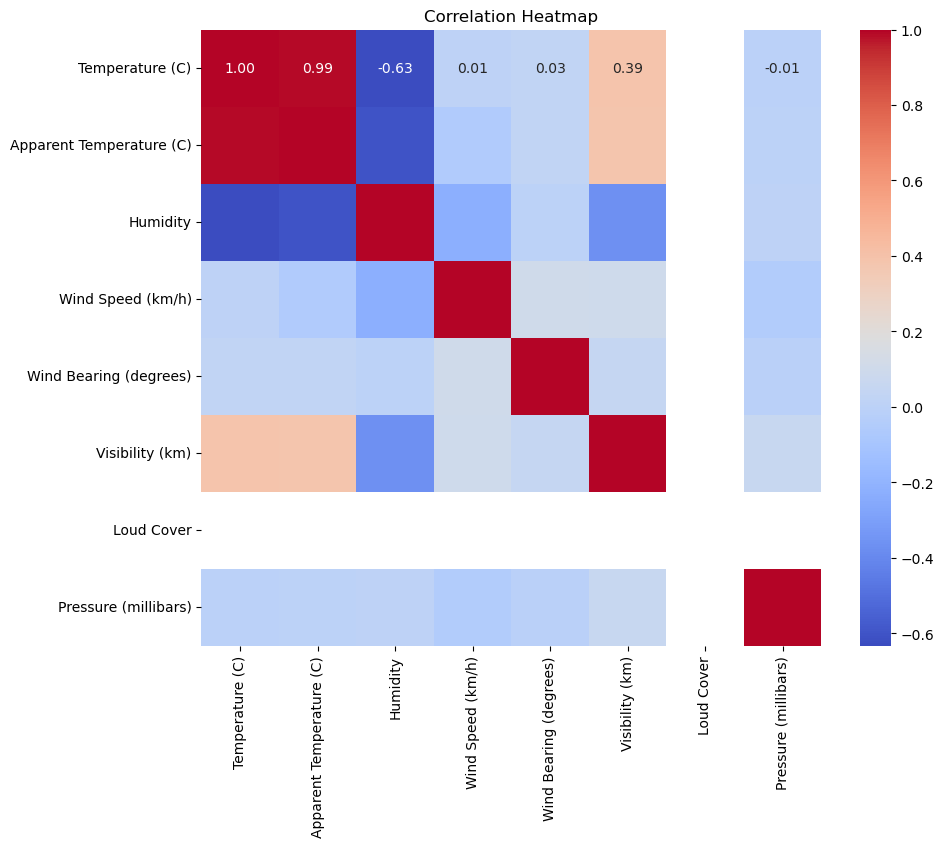

```python
# Plot correlation heatmap
plt.figure(figsize=(10, 8))
sns.heatmap(numeric_df.corr(), annot=True,fmt=".2f", cmap='coolwarm')
plt.title('Correlation Heatmap')
plt.show()
```

**11. What is the minimum and maximum value of each column against each weather condition?**

```python
#minimum
min_df = numeric_df.join(df['Weather_Conditions']).groupby('Weather_Conditions').min()
print(min_df)
```

```
                    Temperature (C)  Apparent Temperature (C)  Humidity  \
Weather_Conditions
rain                       0.005556                 -7.550000       0.0
snow                     -21.822222                -27.716667       0.0

                    Wind Speed (km/h)  Wind Bearing (degrees)  \
Weather_Conditions
rain                              0.0                     0.0
snow                              0.0                     0.0

                    Visibility (km)  Loud Cover  Pressure (millibars)
Weather_Conditions
rain                            0.0         0.0                   0.0
snow                            0.0         0.0                   0.0
```

```python
#maxmum
max_df = numeric_df.join(df['Weather_Conditions']).groupby('Weather_Conditions').max()
print(max_df)
```

```
                    Temperature (C)  Apparent Temperature (C)  Humidity  \
Weather_Conditions
rain                      39.905556                 39.344444       1.0
snow                       0.000000                  0.000000       1.0

                    Wind Speed (km/h)  Wind Bearing (degrees)  \
Weather_Conditions
rain                          63.8526                   359.0
snow                          44.8868                   359.0

                    Visibility (km)  Loud Cover  Pressure (millibars)
Weather_Conditions
rain                           16.1         0.0               1042.38
snow                           16.1         0.0               1046.38
```

```python
df.head()
df.rename(columns = {'Summary':'Sky_Conditions'}, inplace=True)
```

**12. Show all records where sky conditions is 'Partly cloudy'**

```python
df.head(2)
```

|  | Formatted Date | Sky_Conditions | Weather_Conditions | Temperature (C) | Apparent Temperature (C) | Humidity | Wind Speed (km/h) | Wind Bearing (degrees) | Visibility (km) | Loud Cover | Pressure (millibars) | Daily Summary |
| --- | --- | --- | --- | --- | --- | --- | --- | --- | --- | --- | --- | --- |
| 0 | 2006-03-31 22:00:00+00:00 | Partly Cloudy | rain | 9.472222 | 7.388889 | 0.89 | 14.1197 | 251.0 | 15.8263 | 0.0 | 1015.13 | Partly cloudy throughout the day. |
| 1 | 2006-03-31 23:00:00+00:00 | Partly Cloudy | rain | 9.355556 | 7.227778 | 0.86 | 14.2646 | 259.0 | 15.8263 | 0.0 | 1015.63 | Partly cloudy throughout the day. |

```python
df[df.Sky_Conditions == 'Partly Cloudy'] #Answer
```

|  | Formatted Date | Sky_Conditions | Weather_Conditions | Temperature (C) | Apparent Temperature (C) | Humidity | Wind Speed (km/h) | Wind Bearing (degrees) | Visibility (km) | Loud Cover | Pressure (millibars) | Daily Summary |
| --- | --- | --- | --- | --- | --- | --- | --- | --- | --- | --- | --- | --- |
| 0 | 2006-03-31 22:00:00+00:00 | Partly Cloudy | rain | 9.472222 | 7.388889 | 0.89 | 14.1197 | 251.0 | 15.8263 | 0.0 | 1015.13 | Partly cloudy throughout the day. |
| 1 | 2006-03-31 23:00:00+00:00 | Partly Cloudy | rain | 9.355556 | 7.227778 | 0.86 | 14.2646 | 259.0 | 15.8263 | 0.0 | 1015.63 | Partly cloudy throughout the day. |
| 3 | 2006-04-01 01:00:00+00:00 | Partly Cloudy | rain | 8.288889 | 5.944444 | 0.83 | 14.1036 | 269.0 | 15.8263 | 0.0 | 1016.41 | Partly cloudy throughout the day. |
| 5 | 2006-04-01 03:00:00+00:00 | Partly Cloudy | rain | 9.222222 | 7.111111 | 0.85 | 13.9587 | 258.0 | 14.9569 | 0.0 | 1016.66 | Partly cloudy throughout the day. |
| 6 | 2006-04-01 04:00:00+00:00 | Partly Cloudy | rain | 7.733333 | 5.522222 | 0.95 | 12.3648 | 259.0 | 9.9820 | 0.0 | 1016.72 | Partly cloudy throughout the day. |
| ... | ... | ... | ... | ... | ... | ... | ... | ... | ... | ... | ... | ... |
| 96448 | 2016-09-09 17:00:00+00:00 | Partly Cloudy | rain | 26.016667 | 26.016667 | 0.43 | 10.9963 | 31.0 | 16.1000 | 0.0 | 1014.36 | Partly cloudy starting in the morning. |
| 96449 | 2016-09-09 18:00:00+00:00 | Partly Cloudy | rain | 24.583333 | 24.583333 | 0.48 | 10.0947 | 20.0 | 15.5526 | 0.0 | 1015.16 | Partly cloudy starting in the morning. |
| 96450 | 2016-09-09 19:00:00+00:00 | Partly Cloudy | rain | 22.038889 | 22.038889 | 0.56 | 8.9838 | 30.0 | 16.1000 | 0.0 | 1015.66 | Partly cloudy starting in the morning. |
| 96451 | 2016-09-09 20:00:00+00:00 | Partly Cloudy | rain | 21.522222 | 21.522222 | 0.60 | 10.5294 | 20.0 | 16.1000 | 0.0 | 1015.95 | Partly cloudy starting in the morning. |
| 96452 | 2016-09-09 21:00:00+00:00 | Partly Cloudy | rain | 20.438889 | 20.438889 | 0.61 | 5.8765 | 39.0 | 15.5204 | 0.0 | 1016.16 | Partly cloudy starting in the morning. |

31733 rows × 12 columns

**13. Find all instances when 'Sky_Condition' is clear and 'Visibility' is above 15**

```python
df[(df.Sky_Conditions == 'Clear') & (df['Visibility (km)'] > 15)].head(60)
```

|  | Formatted Date | Sky_Conditions | Weather_Conditions | Temperature (C) | Apparent Temperature (C) | Humidity | Wind Speed (km/h) | Wind Bearing (degrees) | Visibility (km) | Loud Cover | Pressure (millibars) | Daily Summary |
| --- | --- | --- | --- | --- | --- | --- | --- | --- | --- | --- | --- | --- |
| 358 | 2006-04-22 20:00:00+00:00 | Clear | rain | 12.244444 | 12.244444 | 0.89 | 1.5295 | 140.0 | 15.8263 | 0.0 | 1015.72 | Foggy starting overnight continuing until morn... |
| 406 | 2006-04-24 20:00:00+00:00 | Clear | rain | 14.905556 | 14.905556 | 0.72 | 3.7513 | 136.0 | 15.8263 | 0.0 | 1019.91 | Partly cloudy until evening. |
| 408 | 2006-04-24 22:00:00+00:00 | Clear | rain | 12.711111 | 12.711111 | 0.89 | 3.2522 | 169.0 | 15.8263 | 0.0 | 1020.11 | Partly cloudy starting in the morning. |
| 432 | 2006-04-25 22:00:00+00:00 | Clear | rain | 13.311111 | 13.311111 | 0.82 | 3.5420 | 73.0 | 15.8263 | 0.0 | 1018.44 | Mostly cloudy starting overnight continuing un... |
| 433 | 2006-04-25 23:00:00+00:00 | Clear | rain | 12.733333 | 12.733333 | 0.83 | 3.0751 | 70.0 | 15.8263 | 0.0 | 1018.23 | Mostly cloudy starting overnight continuing un... |
| 598 | 2006-04-04 20:00:00+00:00 | Clear | rain | 6.677778 | 5.727778 | 0.91 | 5.7960 | 155.0 | 15.8263 | 0.0 | 1015.89 | Mostly cloudy until evening. |
| 670 | 2006-04-07 20:00:00+00:00 | Clear | rain | 3.933333 | 2.422222 | 0.76 | 6.2629 | 268.0 | 15.8263 | 0.0 | 1017.12 | Mostly cloudy until evening. |
| 675 | 2006-04-08 01:00:00+00:00 | Clear | rain | 2.600000 | 0.961111 | 0.85 | 6.0536 | 289.0 | 15.6492 | 0.0 | 1017.33 | Partly cloudy starting in the morning continui... |
| 694 | 2006-04-08 20:00:00+00:00 | Clear | rain | 7.733333 | 6.672222 | 0.65 | 6.7459 | 161.0 | 15.8263 | 0.0 | 1018.28 | Partly cloudy starting in the morning continui... |
| 696 | 2006-04-08 22:00:00+00:00 | Clear | rain | 6.016667 | 4.783333 | 0.74 | 6.4078 | 163.0 | 15.8263 | 0.0 | 1018.39 | Partly cloudy starting in the afternoon. |
| 697 | 2006-04-08 23:00:00+00:00 | Clear | rain | 5.461111 | 4.077778 | 0.76 | 6.6010 | 180.0 | 15.8263 | 0.0 | 1018.49 | Partly cloudy starting in the afternoon. |
| 699 | 2006-04-09 01:00:00+00:00 | Clear | rain | 3.838889 | 2.194444 | 0.82 | 6.6332 | 169.0 | 15.8263 | 0.0 | 1018.18 | Partly cloudy starting in the afternoon. |
| 721 | 2006-07-31 23:00:00+00:00 | Clear | rain | 19.444444 | 19.444444 | 0.90 | 6.0375 | 291.0 | 15.8263 | 0.0 | 1012.22 | Partly cloudy starting overnight. |
| 886 | 2006-08-15 20:00:00+00:00 | Clear | rain | 16.622222 | 16.622222 | 0.93 | 3.1395 | 148.0 | 15.8263 | 0.0 | 1015.88 | Partly cloudy until evening. |
| 923 | 2006-08-17 09:00:00+00:00 | Clear | rain | 26.127778 | 26.127778 | 0.58 | 13.2825 | 189.0 | 15.2628 | 0.0 | 1012.91 | Partly cloudy until morning. |
| 927 | 2006-08-17 13:00:00+00:00 | Clear | rain | 31.133333 | 30.600000 | 0.36 | 11.1734 | 160.0 | 16.0517 | 0.0 | 1011.95 | Partly cloudy until morning. |
| 936 | 2006-08-17 22:00:00+00:00 | Clear | rain | 21.550000 | 21.550000 | 0.81 | 6.3917 | 152.0 | 15.8263 | 0.0 | 1012.66 | Partly cloudy starting overnight continuing un... |
| 937 | 2006-08-17 23:00:00+00:00 | Clear | rain | 21.438889 | 21.438889 | 0.82 | 10.8353 | 150.0 | 15.8263 | 0.0 | 1012.39 | Partly cloudy starting overnight continuing un... |
| 962 | 2006-08-19 00:00:00+00:00 | Clear | rain | 20.955556 | 20.955556 | 0.87 | 3.0751 | 121.0 | 15.8263 | 0.0 | 1016.78 | Partly cloudy starting in the afternoon contin... |
| 963 | 2006-08-19 01:00:00+00:00 | Clear | rain | 18.872222 | 18.872222 | 0.90 | 3.7030 | 237.0 | 15.8263 | 0.0 | 1016.49 | Partly cloudy starting in the afternoon contin... |
| 964 | 2006-08-19 02:00:00+00:00 | Clear | rain | 18.338889 | 18.338889 | 0.93 | 6.4078 | 176.0 | 15.8263 | 0.0 | 1016.69 | Partly cloudy starting in the afternoon contin... |
| 1009 | 2006-08-19 23:00:00+00:00 | Clear | rain | 21.550000 | 21.550000 | 0.87 | 6.1502 | 120.0 | 15.8263 | 0.0 | 1016.90 | Partly cloudy starting in the afternoon. |
| 1011 | 2006-08-20 01:00:00+00:00 | Clear | rain | 19.977778 | 19.977778 | 0.93 | 3.2683 | 129.0 | 15.8263 | 0.0 | 1016.59 | Partly cloudy starting in the afternoon. |
| 1012 | 2006-08-20 02:00:00+00:00 | Clear | rain | 20.994444 | 20.994444 | 0.88 | 6.3595 | 140.0 | 15.8263 | 0.0 | 1016.39 | Partly cloudy starting in the afternoon. |
| 1014 | 2006-08-20 04:00:00+00:00 | Clear | rain | 18.866667 | 18.866667 | 0.97 | 0.0000 | 0.0 | 15.7297 | 0.0 | 1016.34 | Partly cloudy starting in the afternoon. |
| 1033 | 2006-08-20 23:00:00+00:00 | Clear | rain | 19.883333 | 19.883333 | 0.79 | 20.0284 | 318.0 | 15.8263 | 0.0 | 1016.93 | Mostly cloudy starting overnight. |
| 1056 | 2006-08-21 22:00:00+00:00 | Clear | rain | 15.055556 | 15.055556 | 0.87 | 6.9391 | 279.0 | 15.8263 | 0.0 | 1016.27 | Partly cloudy starting in the morning. |
| 1057 | 2006-08-21 23:00:00+00:00 | Clear | rain | 14.988889 | 14.988889 | 0.83 | 11.5598 | 290.0 | 15.8263 | 0.0 | 1016.44 | Partly cloudy starting in the morning. |
| 1059 | 2006-08-22 01:00:00+00:00 | Clear | rain | 13.366667 | 13.366667 | 0.90 | 6.9552 | 280.0 | 15.8263 | 0.0 | 1016.05 | Partly cloudy starting in the morning. |
| 1060 | 2006-08-22 02:00:00+00:00 | Clear | rain | 14.316667 | 14.316667 | 0.84 | 11.5598 | 290.0 | 15.8263 | 0.0 | 1015.86 | Partly cloudy starting in the morning. |
| 1061 | 2006-08-22 03:00:00+00:00 | Clear | rain | 14.338889 | 14.338889 | 0.84 | 16.8889 | 288.0 | 15.2628 | 0.0 | 1015.97 | Partly cloudy starting in the morning. |
| 1224 | 2006-08-28 22:00:00+00:00 | Clear | rain | 13.872222 | 13.872222 | 0.93 | 3.4776 | 202.0 | 15.8263 | 0.0 | 1007.98 | Mostly cloudy starting overnight continuing un... |
| 1441 | 2006-08-08 23:00:00+00:00 | Clear | rain | 15.027778 | 15.027778 | 0.93 | 6.4561 | 232.0 | 15.8263 | 0.0 | 1008.20 | Partly cloudy starting in the morning. |
| 1509 | 2006-12-10 20:00:00+00:00 | Clear | rain | 2.894444 | 1.061111 | 0.92 | 6.7620 | 245.0 | 15.8263 | 0.0 | 1032.00 | Foggy in the morning. |
| 1511 | 2006-12-10 22:00:00+00:00 | Clear | rain | 1.833333 | -1.344444 | 0.92 | 10.9963 | 241.0 | 15.8263 | 0.0 | 1033.41 | Foggy in the morning. |
| 1512 | 2006-12-10 23:00:00+00:00 | Clear | rain | 1.872222 | -0.150000 | 0.91 | 6.8264 | 243.0 | 15.8263 | 0.0 | 1033.20 | Foggy starting in the evening. |
| 1921 | 2006-12-27 00:00:00+00:00 | Clear | snow | -5.461111 | -5.461111 | 0.77 | 3.9445 | 355.0 | 15.1501 | 0.0 | 1038.03 | Partly cloudy starting in the morning continui... |
| 1934 | 2006-12-27 13:00:00+00:00 | Clear | rain | 3.888889 | 1.783333 | 0.65 | 8.2271 | 200.0 | 16.1000 | 0.0 | 1035.40 | Partly cloudy starting in the morning continui... |
| 1935 | 2006-12-27 14:00:00+00:00 | Clear | rain | 3.066667 | 0.700000 | 0.74 | 8.6618 | 190.0 | 16.1000 | 0.0 | 1035.30 | Partly cloudy starting in the morning continui... |
| 2496 | 2006-02-19 23:00:00+00:00 | Clear | rain | 4.561111 | 1.366667 | 0.82 | 14.1358 | 141.0 | 15.8263 | 0.0 | 1011.98 | Mostly cloudy starting overnight continuing un... |
| 2781 | 2006-02-05 20:00:00+00:00 | Clear | snow | -7.222222 | -13.000000 | 0.68 | 13.7655 | 22.0 | 15.8746 | 0.0 | 1027.49 | Foggy starting overnight continuing until morn... |
| 2782 | 2006-02-05 21:00:00+00:00 | Clear | snow | -7.805556 | -13.477778 | 0.71 | 12.8639 | 18.0 | 15.0052 | 0.0 | 1027.43 | Foggy starting overnight continuing until morn... |
| 2783 | 2006-02-05 22:00:00+00:00 | Clear | snow | -8.772222 | -13.988889 | 0.73 | 10.6421 | 11.0 | 15.8263 | 0.0 | 1027.38 | Foggy starting overnight continuing until morn... |
| 2805 | 2006-02-06 20:00:00+00:00 | Clear | snow | -7.938889 | -12.972222 | 0.71 | 10.5938 | 350.0 | 15.8263 | 0.0 | 1028.07 | Partly cloudy in the morning. |
| 2807 | 2006-02-06 22:00:00+00:00 | Clear | snow | -9.538889 | -14.927778 | 0.77 | 10.7065 | 339.0 | 15.8263 | 0.0 | 1028.48 | Partly cloudy in the morning. |
| 2808 | 2006-02-06 23:00:00+00:00 | Clear | snow | -11.083333 | -14.755556 | 0.80 | 6.0214 | 331.0 | 15.7297 | 0.0 | 1028.77 | Mostly cloudy starting in the morning. |
| 3266 | 2006-01-24 01:00:00+00:00 | Clear | snow | -12.316667 | -16.588889 | 0.80 | 6.7781 | 19.0 | 15.8263 | 0.0 | 1043.46 | Partly cloudy starting in the morning continui... |
| 3267 | 2006-01-24 02:00:00+00:00 | Clear | snow | -12.805556 | -16.800000 | 0.76 | 6.1341 | 39.0 | 15.8263 | 0.0 | 1043.46 | Partly cloudy starting in the morning continui... |
| 3269 | 2006-01-24 04:00:00+00:00 | Clear | snow | -13.400000 | -17.694444 | 0.80 | 6.5044 | 23.0 | 15.8263 | 0.0 | 1043.75 | Partly cloudy starting in the morning continui... |
| 3597 | 2006-01-08 20:00:00+00:00 | Clear | snow | -2.755556 | -5.261111 | 0.86 | 6.1985 | 29.0 | 15.6492 | 0.0 | 1036.45 | Partly cloudy in the afternoon. |
| 3673 | 2006-07-10 23:00:00+00:00 | Clear | rain | 18.383333 | 18.383333 | 0.90 | 6.4400 | 350.0 | 15.8263 | 0.0 | 1022.43 | Partly cloudy starting in the afternoon. |
| 3723 | 2006-07-13 01:00:00+00:00 | Clear | rain | 17.777778 | 17.777778 | 0.90 | 6.2146 | 19.0 | 15.8263 | 0.0 | 1017.96 | Partly cloudy until night. |
| 3838 | 2006-07-17 20:00:00+00:00 | Clear | rain | 16.666667 | 16.666667 | 0.70 | 3.1556 | 352.0 | 15.8263 | 0.0 | 1022.75 | Partly cloudy until evening. |
| 3839 | 2006-07-17 21:00:00+00:00 | Clear | rain | 14.833333 | 14.833333 | 0.76 | 3.0590 | 7.0 | 15.3111 | 0.0 | 1023.03 | Partly cloudy until evening. |
| 3840 | 2006-07-17 22:00:00+00:00 | Clear | rain | 14.400000 | 14.400000 | 0.83 | 6.1502 | 321.0 | 15.8263 | 0.0 | 1023.23 | Partly cloudy starting in the morning continui... |
| 3841 | 2006-07-17 23:00:00+00:00 | Clear | rain | 12.827778 | 12.827778 | 0.86 | 6.1019 | 341.0 | 15.8263 | 0.0 | 1023.33 | Partly cloudy starting in the morning continui... |
| 3842 | 2006-07-18 00:00:00+00:00 | Clear | rain | 15.611111 | 15.611111 | 0.80 | 3.1717 | 283.0 | 15.3111 | 0.0 | 1022.31 | Partly cloudy starting in the morning continui... |
| 3864 | 2006-07-18 22:00:00+00:00 | Clear | rain | 16.333333 | 16.333333 | 0.80 | 3.0751 | 280.0 | 15.8263 | 0.0 | 1022.10 | Clear throughout the day. |
| 3865 | 2006-07-18 23:00:00+00:00 | Clear | rain | 16.266667 | 16.266667 | 0.81 | 3.2200 | 240.0 | 16.0517 | 0.0 | 1022.07 | Clear throughout the day. |
| 3867 | 2006-07-19 01:00:00+00:00 | Clear | rain | 15.105556 | 15.105556 | 0.80 | 6.4400 | 250.0 | 15.8263 | 0.0 | 1021.97 | Clear throughout the day. |

```python
df.head(2)
```

|  | Formatted Date | Sky_Conditions | Weather_Conditions | Temperature (C) | Apparent Temperature (C) | Humidity | Wind Speed (km/h) | Wind Bearing (degrees) | Visibility (km) | Loud Cover | Pressure (millibars) | Daily Summary |
| --- | --- | --- | --- | --- | --- | --- | --- | --- | --- | --- | --- | --- |
| 0 | 2006-03-31 22:00:00+00:00 | Partly Cloudy | rain | 9.472222 | 7.388889 | 0.89 | 14.1197 | 251.0 | 15.8263 | 0.0 | 1015.13 | Partly cloudy throughout the day. |
| 1 | 2006-03-31 23:00:00+00:00 | Partly Cloudy | rain | 9.355556 | 7.227778 | 0.86 | 14.2646 | 259.0 | 15.8263 | 0.0 | 1015.63 | Partly cloudy throughout the day. |

```python
df[(df.Sky_Conditions == 'Clear') & (df.Humidity > 0.8) | (df['Visibility (km)'] > 16)]
```

|  | Formatted Date | Sky_Conditions | Weather_Conditions | Temperature (C) | Apparent Temperature (C) | Humidity | Wind Speed (km/h) | Wind Bearing (degrees) | Visibility (km) | Loud Cover | Pressure (millibars) | Daily Summary |
| --- | --- | --- | --- | --- | --- | --- | --- | --- | --- | --- | --- | --- |
| 223 | 2006-04-18 05:00:00+00:00 | Clear | rain | 8.688889 | 8.688889 | 0.93 | 1.4329 | 290.0 | 5.8443 | 0.0 | 1012.96 | Partly cloudy until night. |
| 309 | 2006-04-20 19:00:00+00:00 | Clear | rain | 12.266667 | 12.266667 | 0.99 | 8.0500 | 320.0 | 6.1985 | 0.0 | 1015.76 | Foggy starting overnight continuing until morn... |
| 337 | 2006-04-21 23:00:00+00:00 | Clear | rain | 9.355556 | 8.633333 | 0.96 | 6.4239 | 321.0 | 3.3649 | 0.0 | 1017.56 | Foggy starting overnight continuing until morn... |
| 338 | 2006-04-22 00:00:00+00:00 | Clear | rain | 9.861111 | 9.861111 | 0.96 | 3.2361 | 319.0 | 4.4597 | 0.0 | 1016.16 | Foggy starting overnight continuing until morn... |
| 357 | 2006-04-22 19:00:00+00:00 | Clear | rain | 12.494444 | 12.494444 | 0.91 | 3.9445 | 197.0 | 9.9820 | 0.0 | 1015.51 | Foggy starting overnight continuing until morn... |
| ... | ... | ... | ... | ... | ... | ... | ... | ... | ... | ... | ... | ... |
| 96445 | 2016-09-09 14:00:00+00:00 | Partly Cloudy | rain | 31.083333 | 29.611111 | 0.28 | 13.8943 | 40.0 | 16.1000 | 0.0 | 1013.97 | Partly cloudy starting in the morning. |
| 96447 | 2016-09-09 16:00:00+00:00 | Partly Cloudy | rain | 28.838889 | 27.850000 | 0.32 | 12.2038 | 21.0 | 16.1000 | 0.0 | 1014.07 | Partly cloudy starting in the morning. |
| 96448 | 2016-09-09 17:00:00+00:00 | Partly Cloudy | rain | 26.016667 | 26.016667 | 0.43 | 10.9963 | 31.0 | 16.1000 | 0.0 | 1014.36 | Partly cloudy starting in the morning. |
| 96450 | 2016-09-09 19:00:00+00:00 | Partly Cloudy | rain | 22.038889 | 22.038889 | 0.56 | 8.9838 | 30.0 | 16.1000 | 0.0 | 1015.66 | Partly cloudy starting in the morning. |
| 96451 | 2016-09-09 20:00:00+00:00 | Partly Cloudy | rain | 21.522222 | 21.522222 | 0.60 | 10.5294 | 20.0 | 16.1000 | 0.0 | 1015.95 | Partly cloudy starting in the morning. |

12101 rows × 12 columns